# San Francisco Airbnb Executive Summary

Amy Chen

December 9, 2018

# Overview

Airbnb is a global online hospitality service that connects travellers with lodging from local homeowners. The website and mobile application provide a marketplace for individuals to book or offer rooms. With services across numerous cities across the globe, Airbnb contains massive amounts of data on thousands of listings per region. In particular, San Francisco is where Airbnb was founded, and remains the location of its headquarters. It is a burgeoning city undergoing an economic boom due to the technology industry, and it would be interesting to observe rental housing prices under these circumstances.

# Data

The data used for this analysis is obtained from Inside Airbnb, a website that provides data scraped from public listings on the Airbnb website. I will be analyzing San Francisco data that was compiled on October 03, 2018. In particular, I will be using the “Detailed Listings data for San Francisco” with a file name of “listings.csv.gz”, and “Detailed Review Data for listings in San Francisco” with a file name of “reviews.csv.gz”. These datasets contain information about the same listings, so I will join them together by the variable `listing_id`.

1. Murray Cox, 2018, “Detailed Listings data for San Francisco”, Inside Airbnb, http://insideairbnb.com/get-the-data.html
2. Murray Cox, 2018, “Detailed Review Data for listings in San Francisco”, Inside Airbnb, http://insideairbnb.com/get-the-data.html

# Goals

The primary goal of this analysis is to identify the most important factors that affect housing prices, and attempt to predict prices based on these variables. Additionally, I would like to perform sentiment analysis on the reviews, and provide summary statistics of reviews for each listing.

# Summary of Analysis

After looking at Airbnb listing prices and examining the variables, I concluded that the most important factors that affect price are the type of room and the number of bedrooms. These results are intuitive. However, I would like to focus on more surprising findings.  
While location matters, the data does not provide a good way to include location in a model.

```r
# Load packages
library(tidyverse)
library(ggmap)
library(knitr)
```

```r
# Import datasets
prices <- read_csv(file = ("data/processed/prices.csv"), col_types = cols("n", col_factor(NULL), col_factor(NULL), "n", "n", "n", "c", "n", "n"))

sentiments <- read_csv("data/processed/sentiments.csv")
listings <- read_csv("data/processed/listings.csv")
```

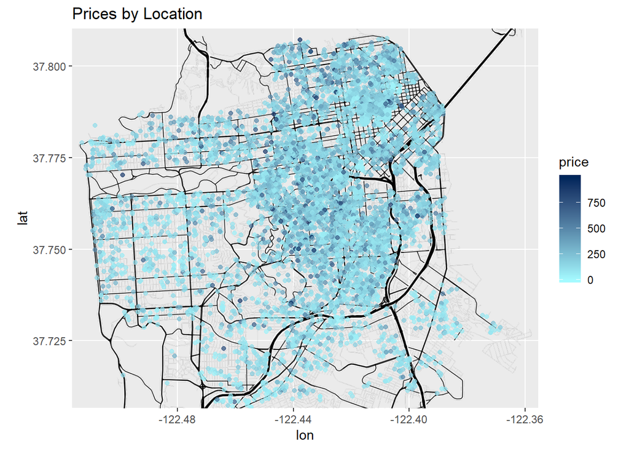

```r
sf <- get_stamenmap(bbox = c(left = -122.5164, bottom = 37.7066, right = -122.3554, top = 37.8103), maptype = c("toner-lines"), zoom = 13)

ggmap(sf) +
  geom_point(data = prices, aes(x = longitude, y = latitude, color = price), alpha = 0.7) +
  scale_colour_gradient(low = '#a4faff', high = '#00275b') +
  labs(title = "Prices by Location")
```

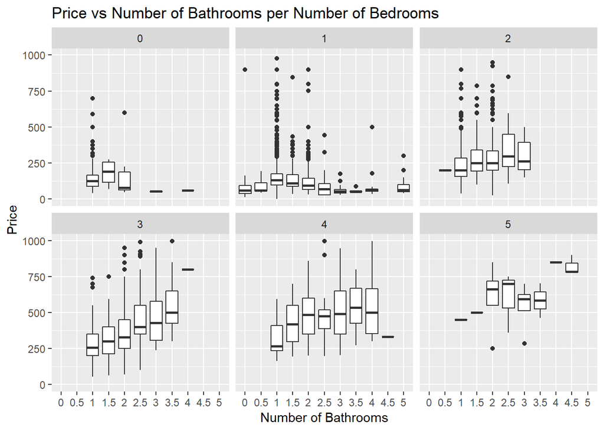

```r
prices %>%
  filter(bedrooms <= 5, bathrooms <= 5) %>%
  ggplot(aes(x = as.factor(bathrooms), y = price)) +
  geom_boxplot() +
  facet_wrap(~bedrooms) +
  labs(title = "Price vs Number of Bathrooms per Number of Bedrooms", x = "Number of Bathrooms", y = "Price")
```

A possible explanation may be that the number of `bathrooms` is dependent on the number of `bedrooms`, and only affects `price` through `bedrooms`.  
The last interesting aspect is the sentiment analysis I performed on reviews. I found sentiment scores by subtracting the number of negative words from the number of positive words in each review, and I averaged the scores.

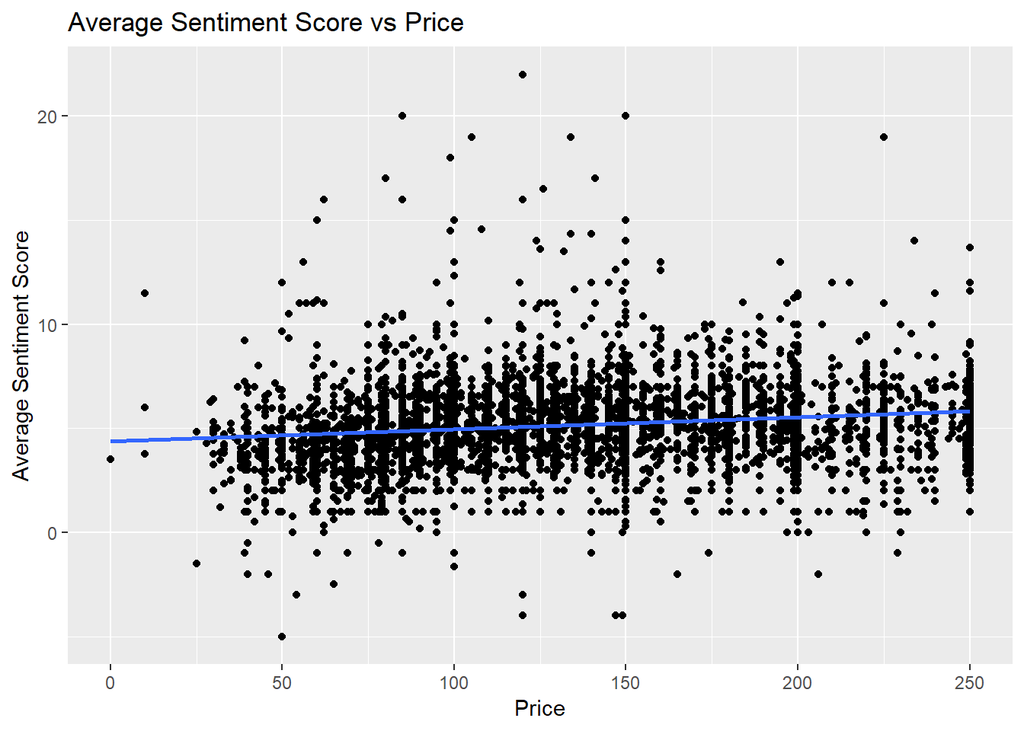

```r
# sentiments per review
listing_sent <- sentiments %>%
  # group by reviewer
  group_by(reviewer_id) %>%
  # count positive and negatve sentiments
  count(listing_id, sentiment) %>%
  # make new positive and negative count columns
  spread(key = sentiment, value = n, fill = 0) %>%
  # calculate overall sentiment per review
  mutate(sent = positive - negative)

# average sentiments per listing
listing_sent <- listing_sent %>%
  # group by listing
  group_by(listing_id) %>%
  # average sentiment per listing
  summarize(avg_sent = mean(sent)) %>%
  # join with original dataset
  left_join(listings, by = c("listing_id" = "id"))

listing_sent %>%
  filter(price <= 250) %>%
  ggplot(aes(x = price, y = avg_sent)) +
  geom_point() +
  geom_smooth(se = FALSE, method = "lm") +
  labs(title = "Average Sentiment Score vs Price",
       x = "Price", y = "Average Sentiment Score")
```